# HW2_Azat-Dovgeldiyev

```python
#import dependencies
import numpy as np
import pandas as pd
import matplotlib.pyplot as plt
```

### Problem 1

#### a.

Create your own KNN classifier function. Your classifier should allow as input the training data matrix, the training labels, the instance to be classified, the value of K, and should return the predicted class for the instance and the indices of the top K neighbors. Your classifier should work with Euclidean distance as well as Cosine distance (which is 1 minus the Cosine similarity). You may create two separate classifiers, or add the distance metric as a parameter in the classifier function (an example implementation of a KNN classifier was provided in class examples).

```python
#read train data then transpose
trainMatMod = pd.read_table("newsgroups/trainMatrixModified.txt", sep="\t", header=None)
trainMatMod=trainMatMod.T
trainMatMod.head()
```

|  | 0 | 1 | 2 | 3 | 4 | 5 | 6 | 7 | 8 | 9 | ... | 5490 | 5491 | 5492 | 5493 | 5494 | 5495 | 5496 | 5497 | 5498 | 5499 |
| --- | --- | --- | --- | --- | --- | --- | --- | --- | --- | --- | --- | --- | --- | --- | --- | --- | --- | --- | --- | --- | --- |
| 0 | 2.0 | 2.0 | 2.0 | 1.0 | 8.0 | 6.0 | 2.0 | 8.0 | 2.0 | 4.0 | ... | 0.0 | 0.0 | 0.0 | 0.0 | 0.0 | 0.0 | 0.0 | 0.0 | 0.0 | 0.0 |
| 1 | 0.0 | 0.0 | 0.0 | 1.0 | 1.0 | 0.0 | 0.0 | 0.0 | 0.0 | 0.0 | ... | 0.0 | 0.0 | 0.0 | 0.0 | 0.0 | 0.0 | 0.0 | 0.0 | 0.0 | 0.0 |
| 2 | 0.0 | 0.0 | 0.0 | 1.0 | 0.0 | 0.0 | 0.0 | 2.0 | 0.0 | 1.0 | ... | 0.0 | 0.0 | 0.0 | 0.0 | 0.0 | 0.0 | 0.0 | 0.0 | 0.0 | 0.0 |
| 3 | 2.0 | 0.0 | 0.0 | 1.0 | 0.0 | 0.0 | 0.0 | 0.0 | 0.0 | 0.0 | ... | 0.0 | 0.0 | 0.0 | 0.0 | 0.0 | 0.0 | 0.0 | 0.0 | 0.0 | 0.0 |
| 4 | 2.0 | 0.0 | 0.0 | 1.0 | 0.0 | 0.0 | 0.0 | 0.0 | 0.0 | 0.0 | ... | 0.0 | 0.0 | 0.0 | 0.0 | 0.0 | 0.0 | 0.0 | 0.0 | 0.0 | 0.0 |

5 rows × 5500 columns

```python
#read test data then transpose
testMatMod = pd.read_table("newsgroups/testMatrixModified.txt", sep="\t", header=None)
testMatMod=testMatMod.T
testMatMod.head()
```

|  | 0 | 1 | 2 | 3 | 4 | 5 | 6 | 7 | 8 | 9 | ... | 5490 | 5491 | 5492 | 5493 | 5494 | 5495 | 5496 | 5497 | 5498 | 5499 |
| --- | --- | --- | --- | --- | --- | --- | --- | --- | --- | --- | --- | --- | --- | --- | --- | --- | --- | --- | --- | --- | --- |
| 0 | 0.0 | 0.0 | 0.0 | 1.0 | 0.0 | 0.0 | 0.0 | 0.0 | 0.0 | 1.0 | ... | 0.0 | 0.0 | 0.0 | 0.0 | 0.0 | 0.0 | 0.0 | 0.0 | 0.0 | 0.0 |
| 1 | 0.0 | 0.0 | 0.0 | 1.0 | 0.0 | 0.0 | 0.0 | 0.0 | 0.0 | 0.0 | ... | 0.0 | 0.0 | 0.0 | 0.0 | 0.0 | 0.0 | 0.0 | 0.0 | 0.0 | 0.0 |
| 2 | 1.0 | 0.0 | 0.0 | 1.0 | 0.0 | 0.0 | 0.0 | 0.0 | 0.0 | 0.0 | ... | 0.0 | 0.0 | 0.0 | 0.0 | 0.0 | 0.0 | 0.0 | 0.0 | 0.0 | 0.0 |
| 3 | 0.0 | 0.0 | 0.0 | 1.0 | 0.0 | 0.0 | 0.0 | 0.0 | 0.0 | 0.0 | ... | 0.0 | 0.0 | 0.0 | 0.0 | 0.0 | 0.0 | 0.0 | 0.0 | 0.0 | 0.0 |
| 4 | 0.0 | 0.0 | 0.0 | 1.0 | 0.0 | 0.0 | 0.0 | 0.0 | 0.0 | 1.0 | ... | 0.0 | 0.0 | 0.0 | 0.0 | 0.0 | 0.0 | 0.0 | 0.0 | 0.0 | 0.0 |

5 rows × 5500 columns

```python
#convert dataframe into arrays
trainMatMod_array = np.array(trainMatMod)
testMatMod_array = np.array(testMatMod)
```

```python
#get labels for training and testing
# we need include index_col to be zero, as files contain only 1 column
train_lbl = pd.read_table("newsgroups/trainClasses.txt", header=None,index_col=0)
test_lbl = pd.read_table("newsgroups/testClasses.txt", header=None,index_col=0)
```

```python
train_lbl=np.array(train_lbl).flatten()
test_lbl=np.array(test_lbl).flatten()
```

```python
#knn search function
def knn_search(x, D, K, measure):
    if measure == 0:
        #euclidean distance from other points
        dists = np.sqrt(((D - x)**2).sum(axis =1))
    elif measure ==1:
        # first find the vector norm for each instance in D as wel as the norm for vector x
        D_norm = np.array([np.linalg.norm(D[i]) for i in range(len(D))])
        x_norm = np.linalg.norm(x)
        # Compute Cosine: divide the dot product o x and each instance in D by the product of the two norms
        sims = np.dot(D,x)/(D_norm * x_norm)
        # The distance measure will be the inverse of Cosine similarity
        dists = 1 - sims
    idx = np.argsort(dists)
    # return the indexes of K nearest neighbors
    return idx[:K], dists
```

```python
def knn_classify(x, D, K, labels, measure):
    from collections import Counter
    neigh_idx, distances = knn_search(x, D, K, measure)
    neigh_labels = labels[neigh_idx]
    count = Counter(neigh_labels)
    return count.most_common(1)[0][0]
```

#### b.

Create an evaluation function to measure the accuracy of your classifier. This function will call the classifier function in part a on all the test instances and in each case compares the actual test class label to the predicted class label. It should take as input the training data, the training labels, the test instances, the labels for test instances, and the value of K. Your evaluation function should return the Classification Accuracy (ratio of correct predictions to the number of test instances)

```python
def knn_evaluate(test_data, train_data, K, train_lbl, measure, test_lbl):
    correct = 0
    for i in range(0,len(test_data)):
        predicted =knn_classify(test_data[i], train_data, K, train_lbl,measure)
        if predicted==test_lbl[i]:
            correct+=1
    #Estimate accuracy rate of the model based on a test set
    accuracy = correct/len(test_data)
    #print("Correct: {}, Total: {}".format(correct, len(test_data)))
    return accuracy
```

#### c

Run your evaluation function on a range of values for K from 5 to 100 (in increments of 5) in order to compare accuracy values for different numbers of neighbors. Do this both using Euclidean Distance as well as Cosine similarity measure. Present the results as graphs with K in the x-axis and the evaluation metric (accuracy) on the y-axis. Use a single plot to compare the two version of the classifier (Eculidean distance version vs. cosine similarity version).

```python
euclidean = []
cosine = []
for K in range(5,101,5):
    euclidean.append(knn_evaluate(testMatMod_array,trainMatMod_array, K, train_lbl,0, test_lbl))
for K in range(5,101,5):
    cosine.append(knn_evaluate(testMatMod_array,trainMatMod_array, K, train_lbl,1, test_lbl))
```

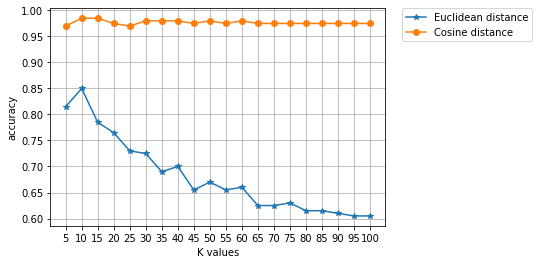

```python
limits = np.arange(5,101,5)
plt.plot(limits,euclidean, label = "Euclidean distance", marker="*")
plt.plot(limits,cosine, label = "Cosine distance", marker="o")
plt.legend(bbox_to_anchor=(1.05,1), loc='upper left',borderaxespad=0.)
plt.xlabel("K values")
plt.ylabel("accuracy")
plt.xticks(np.arange(5,101,5))
plt.grid()
plt.show()
```

#### d.

Next, modify the training and test data sets so that term weights are converted to TFxIDF weights (instead of raw term frequencies).

```python
training = pd.read_table("newsgroups/trainMatrixModified.txt", sep="\t", header=None)
testing = pd.read_table("newsgroups/testMatrixModified.txt", sep="\t", header=None)

DF = pd.DataFrame([(training != 0).sum(axis = 1)]).T
NMatrix  = np.ones(np.shape(training), dtype = float)*800
IDF = np.log2(np.divide(NMatrix,np.array(DF)))
tf_train = np.array((training *IDF).T)
tf_test = np.array((testing *IDF[:,:200]).T)
```

```python
limits = np.arange(5,101,5)
cosine_tf = []
for K in range(5,101,5):
    cosine_tf.append(knn_evaluate(tf_test, tf_train, K, train_lbl, 1, test_lbl))
```

```python
knn_evaluate(tf_test, tf_train, K, train_lbl, 1, test_lbl)
```

```
0.985
```

```python
knn_evaluate(testMatMod_array,trainMatMod_array, K, train_lbl,1, test_lbl)
```

```
0.975
```

**rerun your evaluation (only for the Cosine similairty version of the classifier) on the range of K values**

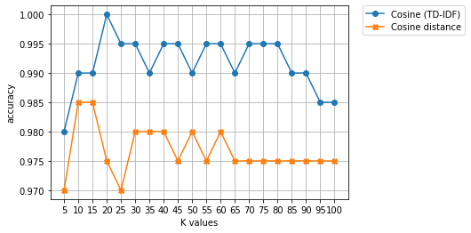

```python
plt.plot(limits,cosine_tf, label = "Cosine (TD-IDF)", marker="o")
plt.plot(limits,cosine, label = "Cosine distance", marker="X")
plt.legend(bbox_to_anchor=(1.05,1), loc='upper left',borderaxespad=0.)
plt.xlabel("K values")
plt.ylabel("accuracy")
plt.xticks(limits)
plt.grid()
plt.show()
```

#### e

*Create a new classifier based on the Rocchio Method adapted for text categorization*  
You should separate the training function from the classifiation function. The training part for the classifier can be implemented as a function that takes as input the training data matrix and the training labels, returning the prototype vectors for each class.

```python
# we create new training labels without converting into arrays
training_labels = pd.read_table("newsgroups/trainClasses.txt", header=None,index_col=0)
test_labels = pd.read_table("newsgroups/testClasses.txt", header=None,index_col=0)

def RocchioMethod_training(data, labels):
    rows, cols = data.shape
    #list of all classes
    classes = np.unique(labels)
    #dictionary for prototype vectors
    prototypes = {}
    for (i, cls) in enumerate(classes):
        #indexes of all docs matching class
        indexes = np.array(labels.index[labels.iloc[:,0] == cls])
        #rows of data
        docs = data[indexes]
        #sum of rows for prototype values
        p = np.sum(docs, axis=0)
        #each value will be assigned to its key
        prototypes.update({i:p})

    return prototypes
```

The classification part can be implemented as another function that would take as input the prototypes returned from the training function and the instance to be classified. This function should measure Cosine similarity of the test instance to each prototype vector. Your output should indicate the predicted class for the test instance and the similarity values of the instance to each of the category prototypes.

```python
def RocchioMethod_classify(prototypes, instance):
    cosine_b = -1
    prototype = -1
    #get cosine similarity of instances and prototype
    for k,v in prototypes.items():
        c = np.dot(instance, v)/(np.linalg.norm(instance) *np.linalg.norm(v))
        if c > cosine_b:
            cosine_b = c
            prototype = k
    return prototype
```

```python
#call function for prototypes given array with training values
prototypes = RocchioMethod_training(trainMatMod_array, training_labels)
```

Finally, use your evaluation function to compare your results to the best KNN results

```python
def RocchioMethod_evaluate(data, labels, prototypes):
    correct = 0
    for i in range(len(data)):
        label =RocchioMethod_classify(prototypes, data[i])
        if label==labels[i]:
            correct+=1
    #Estimate accuracy rate of the model based on a test set
    accuracy = correct/len(data)
    print("Correct: {}, Total: {}".format(correct, len(data)))
    return "Accuracy for Rocchio Method is: {}%".format(accuracy*100)
```

```python
RocchioMethod_evaluate(testMatMod_array,test_lbl,prototypes)
```

```
Correct: 195, Total: 200
```

```
'Accuracy for Rocchio Method is: 97.5%'
```

[Note: your functions should work regardless of the number of categories (class labels) and should not be limited to two-class categorization scenario.]

```python
prototypes1 = RocchioMethod_training(tf_train, training_labels)
```

```python
def RocchioMethod_evaluate_idf(data, labels, prototypes):
    correct = 0
    for i in range(len(data)):
        tf_idf = data[i] * IDF.T[i]
        label =RocchioMethod_classify(prototypes, tf_idf)
        if label==labels[i]:
            correct+=1
    #Estimate accuracy rate of the model based on a test set
    accuracy = correct/len(data)
    print("Correct: {}, Total: {}".format(correct, len(data)))
    return "Accuracy for Rocchio Method is: {}%".format(accuracy*100)
```

```python
RocchioMethod_evaluate_idf(testMatMod_array,test_lbl,prototypes1)
```

```
Correct: 196, Total: 200
```

```
'Accuracy for Rocchio Method is: 98.0%'
```

### Problem 2

#### a

Load and preprocess the data using Pandas or similar tools. Specifically, you need to separate the target attribute ("pep") from the portion of the data to be used for training and testing. You will need to convert the selected dataset into the Standard Spreadsheet format (i.e., convert categorical attributes into numeric by creating dummy variables). Finally, split the transformed data into training and test sets (using 80%-20% randomized split).

```python
bank_pd = pd.read_csv("bank_data.csv")
bank_pd.drop('id',1,inplace=True)
bank_pd.head()
```

|  | age | income | children | gender | region | married | car | savings_acct | current_acct | mortgage | pep |
| --- | --- | --- | --- | --- | --- | --- | --- | --- | --- | --- | --- |
| 0 | 48 | 17546.0 | 1 | FEMALE | INNER_CITY | NO | NO | NO | NO | NO | YES |
| 1 | 40 | 30085.1 | 3 | MALE | TOWN | YES | YES | NO | YES | YES | NO |
| 2 | 51 | 16575.4 | 0 | FEMALE | INNER_CITY | YES | YES | YES | YES | NO | NO |
| 3 | 23 | 20375.4 | 3 | FEMALE | TOWN | YES | NO | NO | YES | NO | NO |
| 4 | 57 | 50576.3 | 0 | FEMALE | RURAL | YES | NO | YES | NO | NO | NO |

```python
y = bank_pd['pep']
y
```

```
0      YES
1       NO
2       NO
3       NO
4       NO
      ...
595     NO
596     NO
597    YES
598     NO
599    YES
Name: pep, Length: 600, dtype: object
```

```python
X=bank_pd.drop('pep',axis = 1)
```

```python
#get dummy variables
X_dummy = pd.get_dummies(X, columns=["gender", "region","married",
                                               "car", "savings_acct", "current_acct",
                                               "mortgage"])
```

```python
X_dummy.head()
```

|  | age | income | children | gender_FEMALE | gender_MALE | region_INNER_CITY | region_RURAL | region_SUBURBAN | region_TOWN | married_NO | married_YES | car_NO | car_YES | savings_acct_NO | savings_acct_YES | current_acct_NO | current_acct_YES | mortgage_NO | mortgage_YES |
| --- | --- | --- | --- | --- | --- | --- | --- | --- | --- | --- | --- | --- | --- | --- | --- | --- | --- | --- | --- |
| 0 | 48 | 17546.0 | 1 | 1 | 0 | 1 | 0 | 0 | 0 | 1 | 0 | 1 | 0 | 1 | 0 | 1 | 0 | 1 | 0 |
| 1 | 40 | 30085.1 | 3 | 0 | 1 | 0 | 0 | 0 | 1 | 0 | 1 | 0 | 1 | 1 | 0 | 0 | 1 | 0 | 1 |
| 2 | 51 | 16575.4 | 0 | 1 | 0 | 1 | 0 | 0 | 0 | 0 | 1 | 0 | 1 | 0 | 1 | 0 | 1 | 1 | 0 |
| 3 | 23 | 20375.4 | 3 | 1 | 0 | 0 | 0 | 0 | 1 | 0 | 1 | 1 | 0 | 1 | 0 | 0 | 1 | 1 | 0 |
| 4 | 57 | 50576.3 | 0 | 1 | 0 | 0 | 1 | 0 | 0 | 0 | 1 | 1 | 0 | 0 | 1 | 1 | 0 | 1 | 0 |

```python
from sklearn.model_selection import train_test_split
X_train, X_test, y_train, y_test = train_test_split(X_dummy, y,test_size=0.2, random_state=42)
```

#### b.

Run scikit-learn's KNN classifier on the test set. Note: in the case of KNN, you should first normalize the data so that all attributes are in the same scale (normalize so that the values are between 0 and 1). Generate the confusion matrix (visualize it using Matplotlib), as well as the classification report. Experiment with different values of K and the weight parameter (i.e., with or without distance weighting) for KNN to see if you can improve accuracy (you do not need to provide the details of all of your experimentation, but provide a short discussion on what parameters worked best as well as your final results).

```python
from sklearn.preprocessing import MinMaxScaler
from sklearn.neighbors import KNeighborsClassifier
from sklearn.metrics import classification_report, confusion_matrix

min_max_scaler = MinMaxScaler().fit(X_train)
X_train_norm = min_max_scaler.transform(X_train)
X_test_norm = min_max_scaler.transform(X_test)
```

```python
n_neighbors = 3
knn_clf = KNeighborsClassifier(n_neighbors, weights = "distance")
knn_clf.fit(X_train_norm, y_train)
```

```
KNeighborsClassifier(algorithm='auto', leaf_size=30, metric='minkowski',
                     metric_params=None, n_jobs=None, n_neighbors=3, p=2,
                     weights='distance')
```

```python
knn_predict_test = knn_clf.predict(X_test_norm)
```

```python
print("Accuracy score for K=3 is {}%".format(knn_clf.score(X_test_norm,y_test)*100))
```

```
Accuracy score for K=3 is 65.0%
```

```python
print(classification_report(y_test, knn_predict_test))
```

```
              precision    recall  f1-score   support

          NO       0.66      0.74      0.70        66
         YES       0.63      0.54      0.58        54

    accuracy                           0.65       120
   macro avg       0.65      0.64      0.64       120
weighted avg       0.65      0.65      0.65       120
```

```
[Text(0, 0.5, 'Yes'), Text(0, 1.5, 'No')]
```

[figure not shown]

```python
import seaborn as sns

ax = plt.subplot()
sns.heatmap(confusion_matrix(y_test, knn_predict_test), annot = True, ax = ax)
ax.set_xlabel("Predicted Class")
ax.set_ylabel("Actual Class")
ax.xaxis.set_ticklabels(["Yes", "No"])
ax.yaxis.set_ticklabels(["Yes", "No"])
```

Accuracies are not much different from each other when K ranges from 1-10, but overall K=3 is the best with 65% accuracy from normalized data. Accuracy decreases after K=5, so there is no point to take larger values for neighbors.

#### c.

Using the non-normalized training and test data, perform classification using scikit-learn's decision tree classifier (using the default parameters). As above, generate the confusion matrix, classification report, and average accuracy scores the classifier. Compare the average accuracy score on the test and the training data sets. What does the comparison tell you in terms of bias-variance trade-off?

```python
X_train, X_test, y_train, y_test = train_test_split(X_dummy, y,test_size=0.2, random_state=42)
```

```python
from sklearn import tree

tree_clf = tree.DecisionTreeClassifier()
tree_clf.fit(X_train, y_train)
tree_predictor = tree_clf.predict(X_test)
```

```python
print(classification_report(y_test, tree_predictor))
```

```
              precision    recall  f1-score   support

          NO       0.90      0.80      0.85        66
         YES       0.79      0.89      0.83        54

    accuracy                           0.84       120
   macro avg       0.84      0.85      0.84       120
weighted avg       0.85      0.84      0.84       120
```

```python
print("Accuracy score with Decision Tree classifier for non-normalized data is {0:0.1f}%".
      format(tree_clf.score(X_test,y_test)*100))
```

```
Accuracy score with Decision Tree classifier for non-normalized data is 84.2%
```

```
[Text(0, 0.5, 'Yes'), Text(0, 1.5, 'No')]
```

[figure not shown]

```python
ax = plt.subplot()
sns.heatmap(confusion_matrix(y_test, tree_predictor), annot = True, ax = ax)
ax.set_xlabel("Predicted Class")
ax.set_ylabel("Actual Class")
ax.xaxis.set_ticklabels(["Yes", "No"])
ax.yaxis.set_ticklabels(["Yes", "No"])
```

Compare the average accuracy score on the test and the training data sets. What does the comparison tell you in terms of bias-variance trade-off?

```python
print("Avg accuracy on TRAIN data: ",tree_clf.score(X_train, y_train))
print("Avg accuracy on TEST data: ",round(tree_clf.score(X_test, y_test),2))
```

```
Avg accuracy on TRAIN data:  1.0
Avg accuracy on TEST data:  0.84
```

Bias-variance trade-off suggests good balance when there are low bias and low variance. In our example above, we have low bias and high variance which leds to overfitting, one suggestion will be to remove noise if necessary, decreasing variance so our model will have good balance.

#### d.

Create another decision tree model (trained on the non-normalized training data) using "entropy" as the selection criteria, min_samples_split=10, and max_depth=5. For this model generate a visualization of tree and submit it as a separate file (png, jpg, or pdf) or embed it in the Jupyter Notebook.

```python
treeCLF = tree.DecisionTreeClassifier(criterion = "entropy", min_samples_split=10, max_depth=5)
treeCLF = treeCLF.fit(X_train,y_train)
```

```python
treeCLF
```

```
DecisionTreeClassifier(ccp_alpha=0.0, class_weight=None, criterion='entropy',
                       max_depth=5, max_features=None, max_leaf_nodes=None,
                       min_impurity_decrease=0.0, min_impurity_split=None,
                       min_samples_leaf=1, min_samples_split=10,
                       min_weight_fraction_leaf=0.0, presort='deprecated',
                       random_state=None, splitter='best')
```

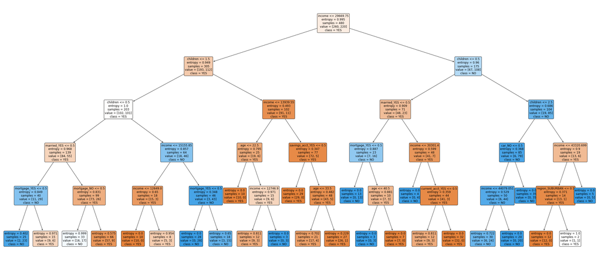

```python
plt.figure(figsize=(45,20))
dtree = tree.plot_tree(treeCLF,feature_names=X_train.columns,
                class_names=y_train.unique(), rounded=True, filled=True, fontsize=12)
plt.savefig("plotTree.png")
```

```python
"""
I saved tree.dot file to convert it into .png later on, since i have environmental issues with graphviz package itself.
Submit both png and dot files.
"""
from sklearn.tree import export_graphviz

export_graphviz(treeCLF,out_file='tree.dot', feature_names=X_train.columns,
                class_names=y_train.unique(),rounded=True, filled=True)
```

### Problem 3. Data Analysis and Predictive Modeling on Census data

#### a.Preprocessing and data analysis:

Examine the data for missing values. In case of categorical attributes, remove instances with missing values. In the case of numeric attributes, impute and fill-in the missing values using the attribute mean.

```python
df = pd.read_csv("adult-modified.csv",na_values=['?'])
df.head()
```

|  | age | workclass | education | marital-status | race | sex | hours-per-week | income |
| --- | --- | --- | --- | --- | --- | --- | --- | --- |
| 0 | 39.0 | Public | 13 | Single | White | Male | 40 | <=50K |
| 1 | 50.0 | Self-emp | 13 | Married | White | Male | 13 | <=50K |
| 2 | 38.0 | Private | 9 | Single | White | Male | 40 | <=50K |
| 3 | 53.0 | Private | 7 | Married | Black | Male | 40 | <=50K |
| 4 | 28.0 | Private | 13 | Married | Black | Female | 40 | <=50K |

```python
df.isnull().sum()
```

```
age               198
workclass         588
education           0
marital-status      0
race                0
sex                 0
hours-per-week      0
income              0
dtype: int64
```

```python
df.age.fillna(df.age.mean(), inplace=True)
df.dropna(inplace=True)
```

```python
df.isnull().sum()
```

```
age               0
workclass         0
education         0
marital-status    0
race              0
sex               0
hours-per-week    0
income            0
dtype: int64
```

Examine the characteristics of the attributes, including summary statistics for the attributes, histograms illustrating the distribtions of numeric attributes, and bar graphs showing value counts for categorical attributes.

```python
df.describe()
```

|  | age | education | hours-per-week |
| --- | --- | --- | --- |
| count | 9412.000000 | 9412.000000 | 9412.000000 |
| mean | 38.366342 | 10.125266 | 41.080217 |
| std | 12.962039 | 2.542118 | 11.884590 |
| min | 17.000000 | 1.000000 | 1.000000 |
| 25% | 28.000000 | 9.000000 | 40.000000 |
| 50% | 37.000000 | 10.000000 | 40.000000 |
| 75% | 47.000000 | 13.000000 | 45.000000 |
| max | 90.000000 | 16.000000 | 99.000000 |

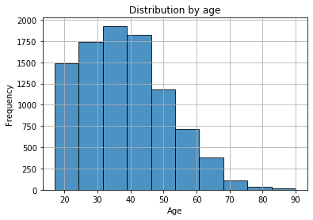

```python
df.age.plot(kind="hist", ec="black", alpha=0.8, grid =True)
plt.title("Distribution by age")
plt.xlabel("Age")
```

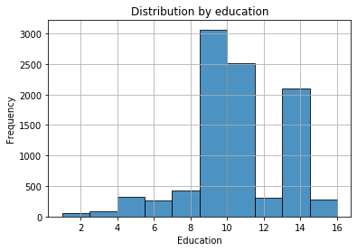

```python
df.education.plot(kind="hist", ec="black", alpha=0.8,grid=True)
plt.title("Distribution by education")
plt.xlabel("Education")
```

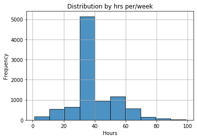

```python
df["hours-per-week"].plot(kind="hist", ec="black", alpha=0.8,grid=True)
plt.title("Distribution by hrs per/week")
plt.xlabel("Hours")
```

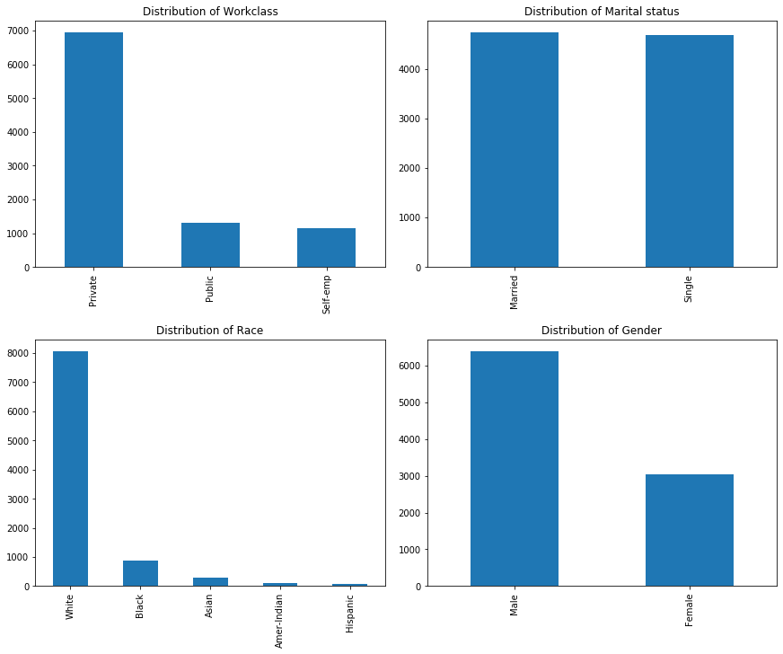

```python
fig, ((ax1, ax2), (ax3, ax4)) = plt.subplots(2, 2,figsize=(12,10),constrained_layout=True)
df["workclass"].value_counts().plot(ax=ax1, kind='bar',title="Distribution of Workclass")
df["marital-status"].value_counts().plot(ax=ax2, kind='bar',title="Distribution of Marital status")
df["race"].value_counts().plot(ax=ax3, kind='bar',title="Distribution of Race")
df["sex"].value_counts().plot(ax=ax4, kind='bar',title="Distribution of Gender")
plt.rcParams['axes.titlesize']=14
```

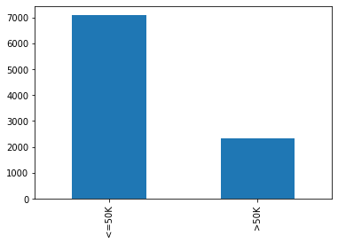

```python
df.income.value_counts().plot(kind="bar")
```

Perform the following cross-tabulations (including generating bar charts): education+race, work-class+income, work-class+race, and race+income. In the latter case (race+income) also create a table or chart showing percentages of each race category that fall in the low-income group. Discuss your observations from this analysis.

```python
edu_by_race = pd.crosstab(df["education"], df["race"])
edu_by_race
```

| race education | Amer-Indian | Asian | Black | Hispanic | White |
| --- | --- | --- | --- | --- | --- |
| 1 | 0 | 0 | 1 | 0 | 11 |
| 2 | 0 | 1 | 4 | 3 | 38 |
| 3 | 0 | 4 | 5 | 1 | 71 |
| 4 | 5 | 5 | 14 | 6 | 150 |
| 5 | 0 | 3 | 19 | 2 | 118 |
| 6 | 8 | 3 | 30 | 4 | 223 |
| 7 | 4 | 6 | 49 | 4 | 261 |
| 8 | 0 | 2 | 17 | 3 | 78 |
| 9 | 35 | 67 | 350 | 23 | 2590 |
| 10 | 26 | 64 | 206 | 11 | 1818 |
| 11 | 5 | 10 | 33 | 4 | 337 |
| 12 | 4 | 5 | 33 | 3 | 259 |
| 13 | 5 | 75 | 102 | 8 | 1387 |
| 14 | 0 | 27 | 20 | 1 | 467 |
| 15 | 0 | 11 | 5 | 2 | 153 |
| 16 | 0 | 8 | 4 | 0 | 101 |

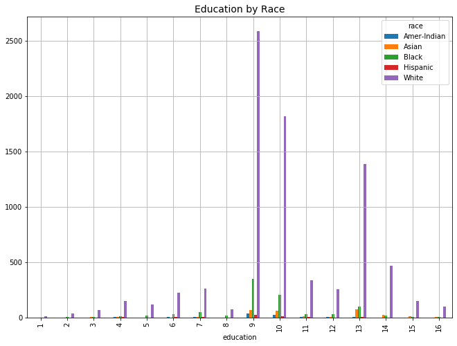

```python
edu_by_race.plot(kind="bar", title ="Education by Race", grid=True)
fig = plt.gcf()
fig.set_size_inches(11,8)
```

```python
work_income = pd.crosstab(df["workclass"], df["income"])
work_income
```

| income workclass | <=50K | >50K |
| --- | --- | --- |
| Private | 5443 | 1504 |
| Public | 925 | 392 |
| Self-emp | 725 | 423 |

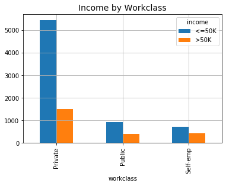

```python
work_income.plot(kind="bar", title ="Income by Workclass", grid=True)
```

```python
work_race = pd.crosstab(df["workclass"], df["race"])
work_race
```

| race workclass | Amer-Indian | Asian | Black | Hispanic | White |
| --- | --- | --- | --- | --- | --- |
| Private | 65 | 204 | 664 | 64 | 5950 |
| Public | 20 | 48 | 192 | 5 | 1052 |
| Self-emp | 7 | 39 | 36 | 6 | 1060 |

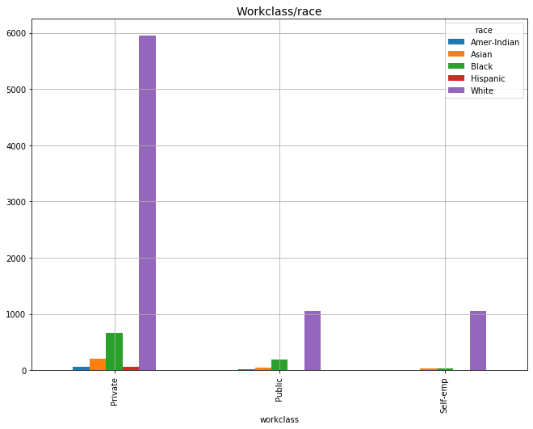

```python
work_race.plot(kind="bar", title ="Workclass/race", grid=True)
fig = plt.gcf()
fig.set_size_inches(11,8)
```

```python
income_race = pd.crosstab(df["race"], df["income"])
income_race
```

| income race | <=50K | >50K |
| --- | --- | --- |
| Amer-Indian | 83 | 9 |
| Asian | 224 | 67 |
| Black | 773 | 119 |
| Hispanic | 69 | 6 |
| White | 5944 | 2118 |

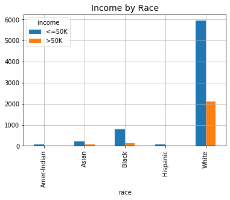

```python
income_race.plot(kind="bar", title ="Income by Race", grid=True)
```

```python
income_race["Percentage of low income"] = round((income_race["<=50K"]/(income_race["<=50K"] + income_race[">50K"]))*100,2)
income_race.sort_values("Percentage of low income", ascending = False)
```

| income race | <=50K | >50K | Percentage of low income |
| --- | --- | --- | --- |
| Hispanic | 69 | 6 | 92.00 |
| Amer-Indian | 83 | 9 | 90.22 |
| Black | 773 | 119 | 86.66 |
| Asian | 224 | 67 | 76.98 |
| White | 5944 | 2118 | 73.73 |

Observation shows, that the white people lead in education, workclass, income by race, and the reason is due to the demographic population. For every workclass percentage of low income is higher than high income. In every workclass the number of white people exceeds.The highest percentage of low income population can be seen in Hispanic race.

Compare and contrast the characteristics of the low-income and high-income categories across the different attributes.

```python
low_income = df[df["income"]=="<=50K"]
high_income = df[df["income"]==">50K"]
```

```python
#High-low income by gender
print("High income by gender:\n{0}\n\n".format(round(high_income['sex'].value_counts(normalize=True) * 100),2))
print("Low income by gender:\n{0}\n\n".format(round(low_income['sex'].value_counts(normalize=True) * 100),2))
```

```
High income by gender:
Male      84.0
Female    16.0
Name: sex, dtype: float64


Low income by gender:
Male      62.0
Female    38.0
Name: sex, dtype: float64
```

The gender distribtion is not equal in our dataset, Major participants are male, more than doubled, only 16% of high and 38% of low income category is composed by female. Female make more low income than high.

```python
#High-low income by workclass
print("High income by gender:\n{0}\n\n".format(round(high_income['workclass'].value_counts(normalize=True) * 100),2))
print("Low income by gender:\n{0}\n\n".format(round(low_income['workclass'].value_counts(normalize=True) * 100),2))
```

```
High income by gender:
Private     65.0
Self-emp    18.0
Public      17.0
Name: workclass, dtype: float64


Low income by gender:
Private     77.0
Public      13.0
Self-emp    10.0
Name: workclass, dtype: float64
```

As we seen in bar graphs above, almost 74% of people are employed by private sectors, thus private sectors consists of 65% of high and 77% low income. Again, employees in private sectors made up higher percentage of low income.

```python
#High-low income by gender
print("High income by gender:\n{0}\n\n".format(round(high_income['marital-status'].value_counts(normalize=True) * 100),2))
print("Low income by gender:\n{0}\n\n".format(round(low_income['marital-status'].value_counts(normalize=True) * 100),2))
```

```
High income by gender:
Married    87.0
Single     13.0
Name: marital-status, dtype: float64


Low income by gender:
Single     62.0
Married    38.0
Name: marital-status, dtype: float64
```

Reasonable statistics shows that married people make up more higher percentage of high income, and single participants make up 62% of low income.

#### b. Predictive Modeling and Model Evaluation:

Using either Pandas or Scikit-learn, create dummy variables for the categorical attributes. Then separate the target attribute ("income*>50K") from the attributes used for training. [Note: you need to drop "income*<=50K" which is also created as a dummy variable in earlier steps). Split the data into training and test sets (80%-20% split).

```python
df_dummies = pd.get_dummies(df)
```

```python
df_dummies.head()
```

|  | age | education | hours-per-week | workclass_Private | workclass_Public | workclass_Self-emp | marital-status_Married | marital-status_Single | race_Amer-Indian | race_Asian | race_Black | race_Hispanic | race_White | sex_Female | sex_Male | income_<=50K | income_>50K |
| --- | --- | --- | --- | --- | --- | --- | --- | --- | --- | --- | --- | --- | --- | --- | --- | --- | --- |
| 0 | 39.0 | 13 | 40 | 0 | 1 | 0 | 0 | 1 | 0 | 0 | 0 | 0 | 1 | 0 | 1 | 1 | 0 |
| 1 | 50.0 | 13 | 13 | 0 | 0 | 1 | 1 | 0 | 0 | 0 | 0 | 0 | 1 | 0 | 1 | 1 | 0 |
| 2 | 38.0 | 9 | 40 | 1 | 0 | 0 | 0 | 1 | 0 | 0 | 0 | 0 | 1 | 0 | 1 | 1 | 0 |
| 3 | 53.0 | 7 | 40 | 1 | 0 | 0 | 1 | 0 | 0 | 0 | 1 | 0 | 0 | 0 | 1 | 1 | 0 |
| 4 | 28.0 | 13 | 40 | 1 | 0 | 0 | 1 | 0 | 0 | 0 | 1 | 0 | 0 | 1 | 0 | 1 | 0 |

```python
target = df_dummies["income_>50K"]
target
```

```
0       0
1       0
2       0
3       0
4       0
       ..
9995    1
9996    0
9997    0
9998    0
9999    0
Name: income_>50K, Length: 9412, dtype: uint8
```

```python
predictor_df = df_dummies.drop(columns = ["income_<=50K", "income_>50K"])
predictor_df.head()
```

|  | age | education | hours-per-week | workclass_Private | workclass_Public | workclass_Self-emp | marital-status_Married | marital-status_Single | race_Amer-Indian | race_Asian | race_Black | race_Hispanic | race_White | sex_Female | sex_Male |
| --- | --- | --- | --- | --- | --- | --- | --- | --- | --- | --- | --- | --- | --- | --- | --- |
| 0 | 39.0 | 13 | 40 | 0 | 1 | 0 | 0 | 1 | 0 | 0 | 0 | 0 | 1 | 0 | 1 |
| 1 | 50.0 | 13 | 13 | 0 | 0 | 1 | 1 | 0 | 0 | 0 | 0 | 0 | 1 | 0 | 1 |
| 2 | 38.0 | 9 | 40 | 1 | 0 | 0 | 0 | 1 | 0 | 0 | 0 | 0 | 1 | 0 | 1 |
| 3 | 53.0 | 7 | 40 | 1 | 0 | 0 | 1 | 0 | 0 | 0 | 1 | 0 | 0 | 0 | 1 |
| 4 | 28.0 | 13 | 40 | 1 | 0 | 0 | 1 | 0 | 0 | 0 | 1 | 0 | 0 | 1 | 0 |

Use scikit-learn to build classifiers usinng Naive Bayes (Gaussian), decision tree (using "gini" as selection criteria), and linear discriminant analysis (LDA). For each of these perform 10-fold cross-validation on the training data (using cross-validation module in scikit-learn) and report the overall average accuracy. Compare this to the model accuracy on the training data. Finally, run your model on the set-aside test data.

```python
dfx_train, dfx_test, dfy_train, dfy_test = train_test_split(predictor_df,
                                                   target, test_size=0.2,
                                                   random_state=42)
```

### Naive Bayes

```python
from sklearn import naive_bayes

n_b = naive_bayes.GaussianNB()
n_b = n_b.fit(dfx_train, dfy_train)
```

```python
from sklearn.model_selection import cross_val_score
cv1 = cross_val_score(n_b, predictor_df, target, cv=10)
print(cv1)
```

```
[0.72823779 0.70488323 0.73113709 0.70669501 0.73219979 0.70563231
 0.7120085  0.7183847  0.73113709 0.7077577 ]
```

```python
print("Naive Bayes overall accuracy: %0.2f (+/- %0.2f)" % (cv1.mean(), cv1.std()*2))
print("Accuracy on Training: {}".format(round(n_b.score(dfx_train, dfy_train),3)))
print("Accuracy on Testing: {}".format(round(n_b.score(dfx_test, dfy_test),3)))
```

```
Naive Bayes overall accuracy: 0.72 (+/- 0.02)
Accuracy on Training: 0.716
Accuracy on Testing: 0.733
```

### Decision tree

```python
d_tree = tree.DecisionTreeClassifier(criterion="gini")
d_tree = d_tree.fit(dfx_train, dfy_train)
```

```python
cv2 = cross_val_score(d_tree, predictor_df, target, cv= 10)
print(cv2)
```

```
[0.75265393 0.77070064 0.77151966 0.77683316 0.77683316 0.76620616
 0.74388948 0.77789586 0.76726886 0.76833156]
```

```python
print("Decision Tree overall accuracy: %0.2f (+/- %0.2f)" % (cv2.mean(), cv2.std()*2))
print("Accuracy on Training: {}".format(round(d_tree.score(dfx_train, dfy_train),3)))
print("Accuracy on Testing: {}".format(round(d_tree.score(dfx_test, dfy_test),3)))
```

```
Decision Tree overall accuracy: 0.77 (+/- 0.02)
Accuracy on Training: 0.943
Accuracy on Testing: 0.751
```

### Linear discriminant analysis

```python
from sklearn.discriminant_analysis import LinearDiscriminantAnalysis as lda

LDA = lda()
LDA = LDA.fit(dfx_train, dfy_train)
```

```python
cv3 = cross_val_score(LDA, predictor_df, target, cv=10)
print(cv3)
```

```
[0.81210191 0.80997877 0.79277365 0.81721573 0.80977683 0.78852285
 0.80021254 0.80765143 0.82146652 0.81615303]
```

```python
print("Linear Discriminant analysis overall accuracy: %0.2f (+/- %0.2f)" % (cv3.mean(), cv3.std()*2))
print("Accuracy on Training: {}".format(round(LDA.score(dfx_train, dfy_train),3)))
print("Accuracy on Testing: {}".format(round(LDA.score(dfx_test, dfy_test),3)))
```

```
Linear Discriminant analysis overall accuracy: 0.81 (+/- 0.02)
Accuracy on Training: 0.809
Accuracy on Testing: 0.81
```

### Summary:

Comparing 3 different models for the given dataset we can see that overall accuracy on training and testing datasets are similar in Naive Bayes and LDA, also LDA gives the best model in predicting higher income with 81%, while accuracy on training is higher in decision trees than testing model.